# Data Wrangling Practical: dplyr

[David Montaner](https://github.com/dmontaner-teaching/gelsk)

2016-08-31

Some practical exercises using the `dplyr` R library.

Clear your session before starting

```r
rm (list = ls ())
```

The following exercises will use the `mtcars` data set distributed with R (`datasets` library). [Here](https://stat.ethz.ch/R-manual/R-devel/library/datasets/html/mtcars.html) you can find some information about the dataset. The same information can be found using the help in your R session `?mtcars`.

# Exercise 1

Use `dplyr` to isolate the columns *mpg* and *wt*. Plot them to explore its correlation.

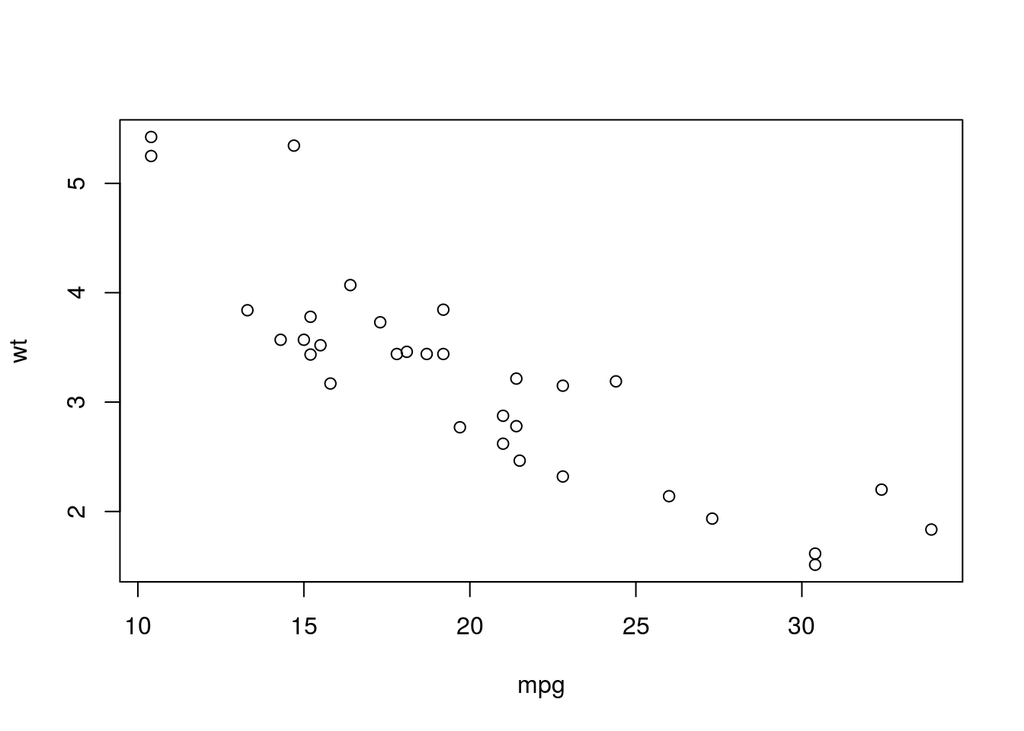

```r
library (dplyr)
mtcars %>%
    select (mpg, wt) %>% plot
```

Make the same plot but just for those cars with automatic transmission (*am = 0*)

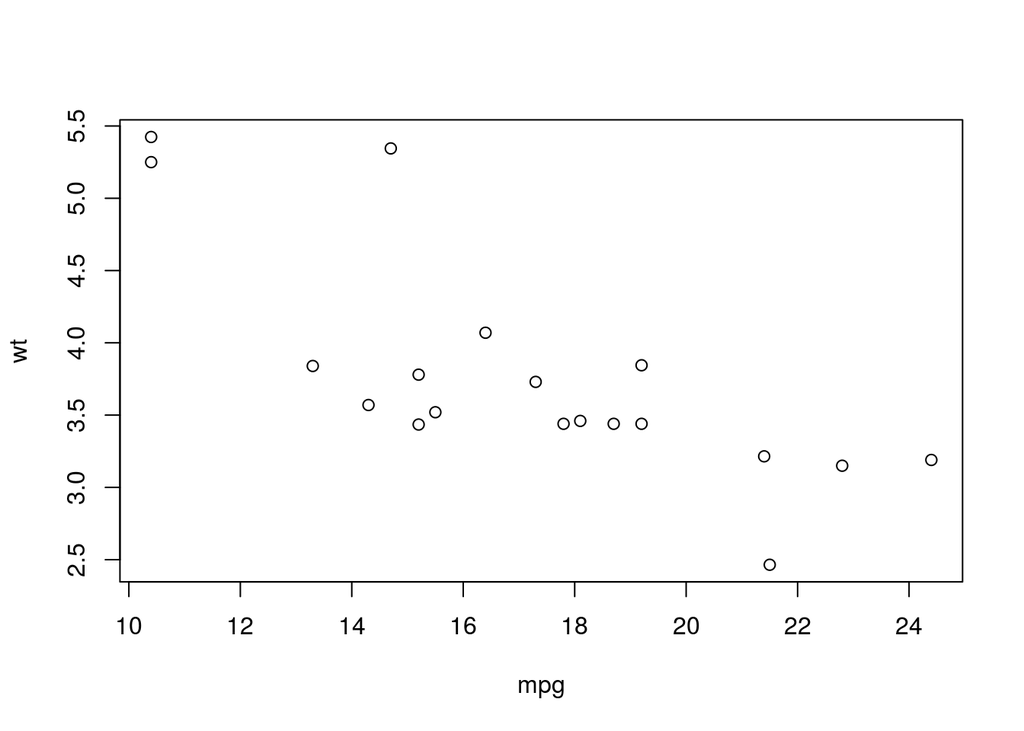

```r
mtcars %>%
    filter (am == 0) %>%
    select (mpg, wt) %>% plot
```

Rename the columns using `dplyr` so that the labels *MilesGallon* and *Weight* appear in the plot,

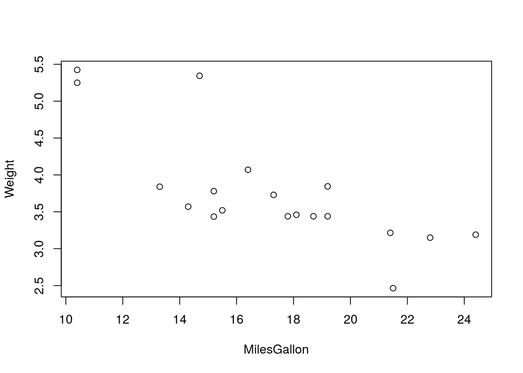

```r
mtcars %>%
    filter (am == 0) %>%
    select (mpg, wt) %>%
    rename (MilesGallon = mpg, Weight = wt) %>%
    plot
```

# Exercise 2

Use `dplyr` to extract the rows in the `mtcars` data set relating *Merc* cars.

```r
mtcars %>%
    add_rownames %>%
    filter (grepl ("Merc", rowname))
```

[output not shown]

# Exercise 3

Use `dplyr` to derive a new variable PowerPerCylinder (hp/cyl) in the `mtcars` data set. Use a `boxplot` to explore its distribution.

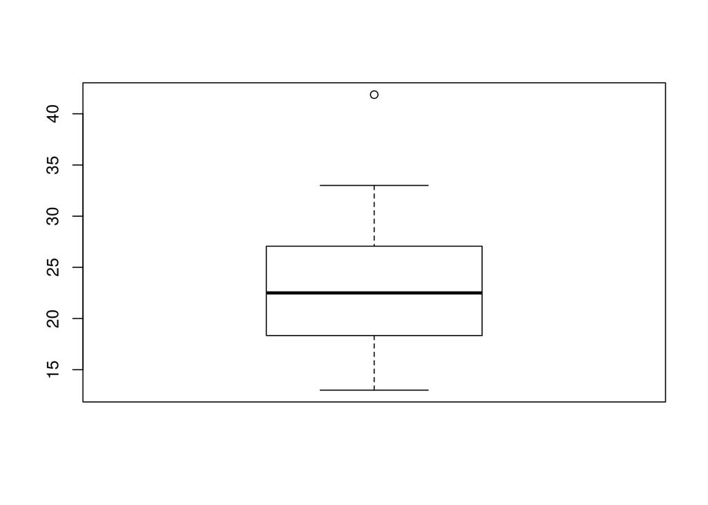

```r
mtcars %>%
    mutate (PowerPerCylinder = hp/cyl) %>%
    select (PowerPerCylinder) %>% boxplot
```

Use `dplyr` to reorder the rows of the `mtcars` so that you can easily find the car with higher PowerPerCylinder.

```r
library (tibble)

mtcars %>%
    ##add_rownames %>%
    rownames_to_column %>%  ## function from `tibble`
    mutate (PowerPerCylinder = hp/cyl) %>%
    arrange (PowerPerCylinder) %>%
    tail

## alternative order

mtcars %>%
    ##add_rownames %>%
    rownames_to_column %>%  ## function from `tibble`
    mutate (PowerPerCylinder = hp/cyl) %>%
    arrange ( - PowerPerCylinder) %>%
    head
```

[output not shown]

# Exercise 4

Use the `mtcars` data set to find out the mean consumption (mpg) of the cars with 3 and 4 gears respectively.

```r
mtcars %>%
    filter ( 5> gear & gear > 2) %>%
    group_by (gear) %>%
    summarise (mean (mpg))
```

[output not shown]

www.dmontaner.com